# Проект: телекоммуникации

**Описание**

Оператор связи намерен бороться с оттоком клиентов. Для этого его руководство хочет, чтобы его сотрудники начали предлагать промокоды и специальные условия всем, кто планирует отказаться от услуг связи. Чтобы заранее выявлять таких пользователей, заказчику нужна модель, которая будет предсказывать, разорвёт ли абонент договор.

Команда оператора собрала персональные данные о некоторых клиентах, информацию об их тарифах и услугах. Наша задача — обучить на этих данных модель для прогноза оттока клиентов.

**План работы**

1. Загрузить и осмотреть данные
2. Выполнить предобработку:
   - привести данные к соответствующим типам
   - стандартизировать наименования столбцов и текстовые категориальные данные
   - удалить дубликаты
   - заполнить пропуски
3. Повести исследовательский анализ данных:
   - Провести анализ количественных признаков
   - Провести анализ временных признаков - дат
   - Провести анализ категориальных признаков
4. Провести корреляционный анализ:
   - На основе имеющихся линейных зависимостей в данных оценить, какие модели следует использовать
   - Оценить, какие признаки следует оставить, а какие явно можно удалить
5. Подготовить данные:
   - Удалить ненужные признаки
   - Выделить тренировочную и тестовую выборки
   - Закодировать и отмасштабировать данные
6. Обучить модели и найти лучшую, которую впоследствии будем тестировать:
   - применить кросс-валидацию для поиска моделей
   - проверить модели на адекватность
   - выбрать лучшую модель, которая подвергнется тестированию
7. Протестировать лучшую найденную модель:
   - оценить её качество на тестовой выборке
   - оценить вклад признаков в классификацию
   - построить матрицу ошибок модели
   - выделить рекомендации по дальнейшему улучшению и работе итоговой модели
8. Написать итоговый вывод

# Содержание

```python
from IPython.display import display, HTML
display(HTML("<style>.container { width:70% !important; }</style>"))
```

# Импорт библиотек. Константы

Обновляем и импортируем библиотеки, объявляем константы.

```python
!pip install numba --upgrade -q
!pip install numpy==1.26.4 -q
!pip install scipy --upgrade -q
!pip install pandas --upgrade -q
!pip install matplotlib --upgrade -q
!pip install seaborn --upgrade -q
!pip install phik --upgrade -q
!pip install scikit-learn --upgrade -q
!pip install imblearn -q

import time
import scipy
import numpy as np
import functools as ft
import re

import pandas as pd
import phik

import matplotlib.pyplot as plt
import seaborn as sns

from sklearn.model_selection import train_test_split
from sklearn.preprocessing import OrdinalEncoder, OneHotEncoder, StandardScaler, RobustScaler, MinMaxScaler
from sklearn.compose import ColumnTransformer
from sklearn.tree import DecisionTreeClassifier
from sklearn.ensemble import RandomForestClassifier
from sklearn.model_selection import RandomizedSearchCV, GridSearchCV
from sklearn.metrics import roc_auc_score, roc_curve, confusion_matrix, precision_score, recall_score
from sklearn.dummy import DummyClassifier

#!pip install LightGBM -q
from lightgbm import LGBMClassifier

#!pip install catboost -q
from catboost import CatBoostClassifier, cv

from imblearn.pipeline import Pipeline

from imblearn.combine import SMOTETomek

RANDOM_STATE = 50824
TEST_SIZE = 0.25
```

[output not shown]

# Функции для проекта

```python
def unique_identifier(df):
    print('#########################')
    for column_name in df.select_dtypes(include='object').columns:
            print(f'unique values in col "{column_name}": {df[column_name].unique()}')
            print('#########################')
```

```python
def dist_density_charts(df):

    fig, ax = plt.subplots(2, 2, figsize=(15, 8))

    row = 0

    for column in df.drop(['begin_date', 'end_date', 'senior_citizen', 'quit'], axis=1).select_dtypes(exclude='object'):

        sns.kdeplot(data=df, x=column, hue='quit', ax=ax[row, 0], multiple='stack', alpha=0.2)

        ax[row, 0].set_title(f"{column}_distribution_density_by_target_chart")

        ax[row, 0].axvline(df.query('quit == 1')[column].median(), color='orange', linestyle='--')
        ax[row, 0].axvline(df.query('quit == 0')[column].median(), color='dodgerblue', linestyle='--')

        ax[row, 0].legend(labels=[f"среднее; ушли: {round(df.query('quit == 1')[column].mean(), 2)}",
                                  f"среднее; остались: {round(df.query('quit == 0')[column].mean(), 2)}"
                                 ]
                         )

        ax[row, 1].boxplot(df[column], vert=False)
        ax[row, 1].set_title(f"{column}_boxplot")
        ax[row, 1].set_xlabel(column)

        ax[row, 1].grid()

        row += 1

    fig.tight_layout()
    plt.show()
```

```python
def date_charts(df):
    fig, ax = plt.subplots(1, 3, figsize=(20, 5))

    sns.histplot(data=df, x='begin_date', hue='quit', ax=ax[0], multiple='stack', alpha=0.2)

    ax[0].set_title(f"begin_date_histplot_by_target")

    ax[0].axvline(df.query('quit == 1')['begin_date'].median(), color='orange', linestyle='--')
    ax[0].axvline(df.query('quit == 0')['begin_date'].median(), color='dodgerblue', linestyle='--')

    ax[0].legend(labels=[f"медиана; ушли: {df.query('quit == 1')['begin_date'].median()}",
                         f"медиана; остались: {df.query('quit == 0')['begin_date'].median()}"
                        ]
                )

    sns.scatterplot(data=df, x='total_charges', y='begin_date', hue='quit', ax=ax[1], alpha=0.6)

    ax[1].set_title(f"total_charges_begin_date_scatterplot_by_target")

    a = ax[1].axhline(df.query('quit == 1')['begin_date'].median(), color='orange', linestyle='--')
    b = ax[1].axhline(df.query('quit == 0')['begin_date'].median(), color='dodgerblue', linestyle='--')

    ax[1].legend(labels=[f"медиана; ушли: {df.query('quit == 1')['begin_date'].median()}",
                         f"медиана; остались: {df.query('quit == 0')['begin_date'].median()}"
                        ],
                 handles = [a, b]
                )

    sns.scatterplot(data=df, x='monthly_charges', y='begin_date', hue='quit', ax=ax[2], alpha=0.6)

    ax[2].set_title(f"monthly_charges_begin_date_scatterplot_by_target")

    a = ax[2].axhline(df.query('quit == 1')['begin_date'].median(), color='orange', linestyle='--')
    b = ax[2].axhline(df.query('quit == 0')['begin_date'].median(), color='dodgerblue', linestyle='--')

    ax[2].legend(labels=[f"медиана; ушли: {df.query('quit == 1')['begin_date'].median()}",
                         f"медиана; остались: {df.query('quit == 0')['begin_date'].median()}"
                        ],
                 handles = [a, b]
                )

    fig.tight_layout()
    plt.show()
```

```python
def duration_charts(df):
    fig, ax = plt.subplots(1, 3, figsize=(20, 5))

    a = 0
    b = 1

    sns.histplot(data=df, x='duration_days', hue='quit', ax=ax[0], multiple='stack', legend='full', alpha=0.2)

    ax[0].set_title("duration_days_histplot_by_target")
    ax[0].legend(labels=['ушли', 'остались'])

    sns.scatterplot(data=df, x='total_charges', y='duration_days', hue='quit', ax=ax[1], legend='full', style='quit', size='quit', sizes=(50, 20), alpha=0.6)

    ax[1].set_title("total_charges_duration_scatterplot_by_target")
    h,l = ax[1].get_legend_handles_labels()
    ax[1].legend(handles=h, labels=['остались', 'ушли'])

    sns.scatterplot(data=df, x='monthly_charges', y='duration_days', hue='quit', ax=ax[2], legend='full', style='quit', size='quit', sizes=(50, 20), alpha=0.6)

    ax[2].set_title("monthly_charges_duration_scatterplot_by_target")
    h,l = ax[2].get_legend_handles_labels()
    ax[2].legend(handles=h, labels=['остались', 'ушли'])


    fig.tight_layout()
    plt.show()
```

```python
def bar_plotter(df):

    data = df.copy()
    data['senior_citizen'] = data['senior_citizen'].astype('object')

    drop_cols = ['customer_id', 'end_date']

    quitters = data.query('quit == 1')
    remainers = data.query('quit == 0')

    fig, ax = plt.subplots(5, 3, figsize=(15, 25))

    row = 0
    col = 0

    for column in data.drop(drop_cols, axis=1).select_dtypes(include='object'):

        info = pd.DataFrame(data.pivot_table(values=['quit'], columns=[column], aggfunc='value_counts'))

        ax[row, col] = sns.barplot(data=info, x=column, y='count', hue='quit', ax=ax[row, col])

        ax[row, col].bar_label(ax[row, col].containers[0], fontsize=10)
        ax[row, col].bar_label(ax[row, col].containers[1], fontsize=10)

        h,l = ax[row, col].get_legend_handles_labels()
        ax[row, col].legend(handles=h, labels=['остались', 'ушли'])

        ax[row, col].set_title('{}_chart'.format(column))

        ax[row, col].xaxis.label.set_visible(False)

        ax[row, col].grid(axis='y')

        plt.setp(ax[row, col].get_xticklabels(), rotation=-15, ha="left", rotation_mode="anchor")

        if col < 2:
            col += 1
        else:
            row += 1
            col = 0


    fig.tight_layout()
    plt.show()
```

```python
def recall_threshold_table(model, X_test, y_test, linspace_start=0, linspace_end=1, linspace_num=5):

    y_proba = model.predict_proba(X_test)[:, 1]

    data = pd.DataFrame(zip(y_test, y_proba),
                        columns=['y_valid', 'y_proba']).sort_values(by='y_proba', ascending=False)

    thresholds = [round(i, 2) for i in np.linspace(linspace_start, linspace_end, num=linspace_num, endpoint=False)]

    columns = []

    for i in thresholds:
        columns.append('y_pred_' + str(i))
        data['y_pred_' + str(i)] = data['y_proba'].apply(lambda x: 1 if x >= i else 0)

    recall_list = []
    predicted_objects = []
    all_objects_class_1 = data.loc[data['y_valid'] == 1, 'y_valid'].count()

    for column in data.drop(['y_valid', 'y_proba'], axis=1).columns:
        recall_list.append(round(recall_score(data['y_valid'], data[column]), 2))
        predicted_objects.append(data.loc[(data[column] == 1) & (data['y_valid'] == 1)][column].count())

    recall_thresholds = {'порог': data.drop(['y_valid', 'y_proba'], axis=1).columns,
                         'recall': recall_list,
                         'число верно предсказанных объектов': predicted_objects,
                         'всего объектов класса 1': all_objects_class_1
                        }

    rt_info = pd.DataFrame(recall_thresholds)

    return rt_info
```

## Шаг. Загрузка данных

Загрузим первый датасет с информацией о датах заключения и расторжения (при наличии) контракта и платежах. Сразу запарсим даты старта соглашения, с датами окончания разберемся потом. Осмотрим датасет.

```python
df1 = pd.read_csv(r'C:\Users\paul-\Desktop\telecom_project\contract_new.csv', parse_dates=['BeginDate'])
display(df1.head(5))
print(df1.info())
```

|  | customerID | BeginDate | EndDate | Type | PaperlessBilling | PaymentMethod | MonthlyCharges | TotalCharges |
| --- | --- | --- | --- | --- | --- | --- | --- | --- |
| 0 | 7590-VHVEG | 2020-01-01 | No | Month-to-month | Yes | Electronic check | 29.85 | 31.04 |
| 1 | 5575-GNVDE | 2017-04-01 | No | One year | No | Mailed check | 56.95 | 2071.84 |
| 2 | 3668-QPYBK | 2019-10-01 | No | Month-to-month | Yes | Mailed check | 53.85 | 226.17 |
| 3 | 7795-CFOCW | 2016-05-01 | No | One year | No | Bank transfer (automatic) | 42.30 | 1960.6 |
| 4 | 9237-HQITU | 2019-09-01 | No | Month-to-month | Yes | Electronic check | 70.70 | 353.5 |

```
<class 'pandas.core.frame.DataFrame'>
RangeIndex: 7043 entries, 0 to 7042
Data columns (total 8 columns):
 #   Column            Non-Null Count  Dtype
---  ------            --------------  -----
 0   customerID        7043 non-null   object
 1   BeginDate         7043 non-null   datetime64[ns]
 2   EndDate           7043 non-null   object
 3   Type              7043 non-null   object
 4   PaperlessBilling  7043 non-null   object
 5   PaymentMethod     7043 non-null   object
 6   MonthlyCharges    7043 non-null   float64
 7   TotalCharges      7043 non-null   object
dtypes: datetime64[ns](1), float64(1), object(6)
memory usage: 440.3+ KB
None
```

У нас 7043 объекта, пропусков нет. Данные в столбцах приведены к соответствующим типам, за исключением колонки 'TotalCharges'. Похоже, какие-то строки помешали pandas загрузить данные в столбце сразу как float. Попробуем сразу привести их к нужному типу:

```python
df1['TotalCharges'] = df1['TotalCharges'].str.replace(r'[^0-9.]', 'NA', regex=True).replace('NA', np.nan).astype(float)
```

Проверяем.

```python
print(df1.info())
```

```
<class 'pandas.core.frame.DataFrame'>
RangeIndex: 7043 entries, 0 to 7042
Data columns (total 8 columns):
 #   Column            Non-Null Count  Dtype
---  ------            --------------  -----
 0   customerID        7043 non-null   object
 1   BeginDate         7043 non-null   datetime64[ns]
 2   EndDate           7043 non-null   object
 3   Type              7043 non-null   object
 4   PaperlessBilling  7043 non-null   object
 5   PaymentMethod     7043 non-null   object
 6   MonthlyCharges    7043 non-null   float64
 7   TotalCharges      7032 non-null   float64
dtypes: datetime64[ns](1), float64(2), object(5)
memory usage: 440.3+ KB
None
```

Всё нормально, теперь у нас есть 11 пропусков в столбце 'TotalCharges', но зато он приведен к нужному типу. Пропусков немного, поэтому данные с ними можно удалить. Удобнее будет сделать это далее, после объединения всех датафреймов в один.

Загружаем и осматриваем второй датасет с личными данными клиентов.

```python
df2 = pd.read_csv('r'C:\Users\paul-\Desktop\telecom_project\personal_new.csv')
display(df2.head(5))
print(df2.info())
```

|  | customerID | gender | SeniorCitizen | Partner | Dependents |
| --- | --- | --- | --- | --- | --- |
| 0 | 7590-VHVEG | Female | 0 | Yes | No |
| 1 | 5575-GNVDE | Male | 0 | No | No |
| 2 | 3668-QPYBK | Male | 0 | No | No |
| 3 | 7795-CFOCW | Male | 0 | No | No |
| 4 | 9237-HQITU | Female | 0 | No | No |

```
<class 'pandas.core.frame.DataFrame'>
RangeIndex: 7043 entries, 0 to 7042
Data columns (total 5 columns):
 #   Column         Non-Null Count  Dtype
---  ------         --------------  -----
 0   customerID     7043 non-null   object
 1   gender         7043 non-null   object
 2   SeniorCitizen  7043 non-null   int64
 3   Partner        7043 non-null   object
 4   Dependents     7043 non-null   object
dtypes: int64(1), object(4)
memory usage: 275.2+ KB
None
```

Здесь все хорошо. Пропусков нет, данные приведены к соответствующим типам. Загрузим третий датасет с данными об услугах.

```python
df3 = pd.read_csv('r'C:\Users\paul-\Desktop\telecom_project\internet_new.csv')
display(df3.head(5))
print(df3.info())
```

|  | customerID | InternetService | OnlineSecurity | OnlineBackup | DeviceProtection | TechSupport | StreamingTV | StreamingMovies |
| --- | --- | --- | --- | --- | --- | --- | --- | --- |
| 0 | 7590-VHVEG | DSL | No | Yes | No | No | No | No |
| 1 | 5575-GNVDE | DSL | Yes | No | Yes | No | No | No |
| 2 | 3668-QPYBK | DSL | Yes | Yes | No | No | No | No |
| 3 | 7795-CFOCW | DSL | Yes | No | Yes | Yes | No | No |
| 4 | 9237-HQITU | Fiber optic | No | No | No | No | No | No |

```
<class 'pandas.core.frame.DataFrame'>
RangeIndex: 5517 entries, 0 to 5516
Data columns (total 8 columns):
 #   Column            Non-Null Count  Dtype
---  ------            --------------  -----
 0   customerID        5517 non-null   object
 1   InternetService   5517 non-null   object
 2   OnlineSecurity    5517 non-null   object
 3   OnlineBackup      5517 non-null   object
 4   DeviceProtection  5517 non-null   object
 5   TechSupport       5517 non-null   object
 6   StreamingTV       5517 non-null   object
 7   StreamingMovies   5517 non-null   object
dtypes: object(8)
memory usage: 344.9+ KB
None
```

Здесь тоже всё хорошо, пропусков нет, типы соответствующие. Теперь посмотрим на последний датасет.

```python
df4 = pd.read_csv('r'C:\Users\paul-\Desktop\telecom_project\phone_new.csv')
display(df4.head(5))
print(df4.info())
```

|  | customerID | MultipleLines |
| --- | --- | --- |
| 0 | 5575-GNVDE | No |
| 1 | 3668-QPYBK | No |
| 2 | 9237-HQITU | No |
| 3 | 9305-CDSKC | Yes |
| 4 | 1452-KIOVK | Yes |

```
<class 'pandas.core.frame.DataFrame'>
RangeIndex: 6361 entries, 0 to 6360
Data columns (total 2 columns):
 #   Column         Non-Null Count  Dtype
---  ------         --------------  -----
 0   customerID     6361 non-null   object
 1   MultipleLines  6361 non-null   object
dtypes: object(2)
memory usage: 99.5+ KB
None
```

Здесь всё то же самое.

Для удобства в дальнейшей работе, пожалуй, объединим все наши датафреймы в один, используя юзер-ID в качестве ключа.

```python
dfs = [df1, df2, df3, df4]
df = ft.reduce(lambda left, right: pd.merge(left, right, how='outer', on='customerID'), dfs)
```

Посмотрим на итоговый датафрейм.

```python
display(df.sample(10, random_state=RANDOM_STATE))
print(df.info())
```

|  | customerID | BeginDate | EndDate | Type | PaperlessBilling | PaymentMethod | MonthlyCharges | TotalCharges | gender | SeniorCitizen | Partner | Dependents | InternetService | OnlineSecurity | OnlineBackup | DeviceProtection | TechSupport | StreamingTV | StreamingMovies | MultipleLines |
| --- | --- | --- | --- | --- | --- | --- | --- | --- | --- | --- | --- | --- | --- | --- | --- | --- | --- | --- | --- | --- |
| 6759 | 9593-CVZKR | 2015-06-01 | No | Two year | Yes | Mailed check | 24.45 | 1369.20 | Female | 0 | Yes | Yes | NaN | NaN | NaN | NaN | NaN | NaN | NaN | Yes |
| 5020 | 7055-HNEOJ | 2019-11-01 | No | Month-to-month | Yes | Mailed check | 55.80 | 167.40 | Male | 0 | Yes | No | DSL | No | No | Yes | Yes | No | No | No |
| 1600 | 2325-ZUSFD | 2015-01-01 | 2018-04-01 | One year | Yes | Bank transfer (automatic) | 70.10 | 2788.58 | Female | 0 | Yes | Yes | DSL | Yes | No | No | No | Yes | Yes | No |
| 934 | 1353-LJWEM | 2019-03-01 | No | Month-to-month | Yes | Electronic check | 60.90 | 690.00 | Male | 0 | No | No | DSL | No | Yes | Yes | Yes | No | No | No |
| 3974 | 5599-HVLTW | 2018-12-01 | No | Month-to-month | Yes | Bank transfer (automatic) | 80.35 | 1124.90 | Female | 1 | No | No | Fiber optic | No | No | Yes | No | No | No | Yes |
| 2347 | 3363-DTIVD | 2014-03-01 | 2016-07-01 | Two year | No | Electronic check | 105.55 | 3044.06 | Male | 0 | Yes | Yes | Fiber optic | Yes | No | Yes | No | Yes | Yes | Yes |
| 2626 | 3736-BLEPA | 2017-10-01 | No | One year | Yes | Bank transfer (automatic) | 91.25 | 2555.00 | Male | 0 | No | No | Fiber optic | No | Yes | No | Yes | Yes | No | No |
| 3713 | 5223-UZAVK | 2014-10-01 | 2017-05-01 | One year | Yes | Credit card (automatic) | 100.30 | 3109.30 | Male | 0 | No | No | Fiber optic | Yes | Yes | No | No | Yes | Yes | No |
| 60 | 0104-PPXDV | 2015-04-01 | No | One year | No | Credit card (automatic) | 50.30 | 3004.92 | Male | 0 | Yes | No | DSL | No | No | Yes | No | No | No | No |
| 4945 | 6963-KQYQB | 2014-04-01 | No | Two year | No | Mailed check | 24.05 | 1767.68 | Female | 0 | Yes | Yes | NaN | NaN | NaN | NaN | NaN | NaN | NaN | Yes |

```
<class 'pandas.core.frame.DataFrame'>
RangeIndex: 7043 entries, 0 to 7042
Data columns (total 20 columns):
 #   Column            Non-Null Count  Dtype
---  ------            --------------  -----
 0   customerID        7043 non-null   object
 1   BeginDate         7043 non-null   datetime64[ns]
 2   EndDate           7043 non-null   object
 3   Type              7043 non-null   object
 4   PaperlessBilling  7043 non-null   object
 5   PaymentMethod     7043 non-null   object
 6   MonthlyCharges    7043 non-null   float64
 7   TotalCharges      7032 non-null   float64
 8   gender            7043 non-null   object
 9   SeniorCitizen     7043 non-null   int64
 10  Partner           7043 non-null   object
 11  Dependents        7043 non-null   object
 12  InternetService   5517 non-null   object
 13  OnlineSecurity    5517 non-null   object
 14  OnlineBackup      5517 non-null   object
 15  DeviceProtection  5517 non-null   object
 16  TechSupport       5517 non-null   object
 17  StreamingTV       5517 non-null   object
 18  StreamingMovies   5517 non-null   object
 19  MultipleLines     6361 non-null   object
dtypes: datetime64[ns](1), float64(2), int64(1), object(16)
memory usage: 1.1+ MB
None
```

Всё в порядке, можно приступать к предобработке и анализу.

## шаг. Предобработка данных

Сначала стандартизируем названия столбцов и текстовые данные: приведем их к змеиному регистру.

```python
df.columns = [re.sub(r'(?<!^)(?=[A-Z])', '_', i).lower() for i in df.columns]
try:
    df.rename(columns={'customer_i_d': 'customer_id', 'streaming_t_v': 'streaming_tv'}, inplace=True)
except:
    pass

for column in df.select_dtypes('object').columns:
    if column not in ['end_date' , 'customer_id']:
        df[column] = df[column].str.lower()
        df[column] = df[column].str.replace(r'[- ()]',
                                            '_',
                                            regex=True
                                           ).str.replace(r'__',
                                                         '_',
                                                         regex=True
                                                        ).str.replace(r'_$',
                                                                      '',
                                                                      regex=True
                                                                     )
df['end_date'] = df['end_date'].str.lower()
```

Смотрим, всё ли в порядке.

```python
display(df.sample(10, random_state=RANDOM_STATE))
print(df.info())
```

|  | customer_id | begin_date | end_date | type | paperless_billing | payment_method | monthly_charges | total_charges | gender | senior_citizen | partner | dependents | internet_service | online_security | online_backup | device_protection | tech_support | streaming_tv | streaming_movies | multiple_lines |
| --- | --- | --- | --- | --- | --- | --- | --- | --- | --- | --- | --- | --- | --- | --- | --- | --- | --- | --- | --- | --- |
| 6759 | 9593-CVZKR | 2015-06-01 | no | two_year | yes | mailed_check | 24.45 | 1369.20 | female | 0 | yes | yes | NaN | NaN | NaN | NaN | NaN | NaN | NaN | yes |
| 5020 | 7055-HNEOJ | 2019-11-01 | no | month_to_month | yes | mailed_check | 55.80 | 167.40 | male | 0 | yes | no | dsl | no | no | yes | yes | no | no | no |
| 1600 | 2325-ZUSFD | 2015-01-01 | 2018-04-01 | one_year | yes | bank_transfer_automatic | 70.10 | 2788.58 | female | 0 | yes | yes | dsl | yes | no | no | no | yes | yes | no |
| 934 | 1353-LJWEM | 2019-03-01 | no | month_to_month | yes | electronic_check | 60.90 | 690.00 | male | 0 | no | no | dsl | no | yes | yes | yes | no | no | no |
| 3974 | 5599-HVLTW | 2018-12-01 | no | month_to_month | yes | bank_transfer_automatic | 80.35 | 1124.90 | female | 1 | no | no | fiber_optic | no | no | yes | no | no | no | yes |
| 2347 | 3363-DTIVD | 2014-03-01 | 2016-07-01 | two_year | no | electronic_check | 105.55 | 3044.06 | male | 0 | yes | yes | fiber_optic | yes | no | yes | no | yes | yes | yes |
| 2626 | 3736-BLEPA | 2017-10-01 | no | one_year | yes | bank_transfer_automatic | 91.25 | 2555.00 | male | 0 | no | no | fiber_optic | no | yes | no | yes | yes | no | no |
| 3713 | 5223-UZAVK | 2014-10-01 | 2017-05-01 | one_year | yes | credit_card_automatic | 100.30 | 3109.30 | male | 0 | no | no | fiber_optic | yes | yes | no | no | yes | yes | no |
| 60 | 0104-PPXDV | 2015-04-01 | no | one_year | no | credit_card_automatic | 50.30 | 3004.92 | male | 0 | yes | no | dsl | no | no | yes | no | no | no | no |
| 4945 | 6963-KQYQB | 2014-04-01 | no | two_year | no | mailed_check | 24.05 | 1767.68 | female | 0 | yes | yes | NaN | NaN | NaN | NaN | NaN | NaN | NaN | yes |

```
<class 'pandas.core.frame.DataFrame'>
RangeIndex: 7043 entries, 0 to 7042
Data columns (total 20 columns):
 #   Column             Non-Null Count  Dtype
---  ------             --------------  -----
 0   customer_id        7043 non-null   object
 1   begin_date         7043 non-null   datetime64[ns]
 2   end_date           7043 non-null   object
 3   type               7043 non-null   object
 4   paperless_billing  7043 non-null   object
 5   payment_method     7043 non-null   object
 6   monthly_charges    7043 non-null   float64
 7   total_charges      7032 non-null   float64
 8   gender             7043 non-null   object
 9   senior_citizen     7043 non-null   int64
 10  partner            7043 non-null   object
 11  dependents         7043 non-null   object
 12  internet_service   5517 non-null   object
 13  online_security    5517 non-null   object
 14  online_backup      5517 non-null   object
 15  device_protection  5517 non-null   object
 16  tech_support       5517 non-null   object
 17  streaming_tv       5517 non-null   object
 18  streaming_movies   5517 non-null   object
 19  multiple_lines     6361 non-null   object
dtypes: datetime64[ns](1), float64(2), int64(1), object(16)
memory usage: 1.1+ MB
None
```

Вроде бы все хорошо, ничего не потерялось, пробелы заменены. Теперь проверим категориальные значения на наличие неявных дубликатов.

```python
unique_identifier(df.drop(['customer_id'], axis=1))
```

```
#########################
unique values in col "end_date": ['no' '2020-01-01' '2016-06-01' '2016-03-01' '2017-02-01' '2019-09-01'
 '2016-07-01' '2017-05-01' '2019-05-01' '2019-06-01' '2019-02-01'
 '2018-04-01' '2016-11-01' '2016-09-01' '2019-04-01' '2019-10-01'
 '2015-11-01' '2019-01-01' '2018-09-01' '2017-08-01' '2018-08-01'
 '2017-12-01' '2018-01-01' '2014-09-01' '2017-06-01' '2019-08-01'
 '2016-01-01' '2017-07-01' '2018-06-01' '2018-11-01' '2018-10-01'
 '2016-02-01' '2019-07-01' '2018-05-01' '2016-08-01' '2018-02-01'
 '2019-12-01' '2018-03-01' '2018-07-01' '2015-05-01' '2017-11-01'
 '2019-03-01' '2015-02-01' '2017-09-01' '2016-10-01' '2017-10-01'
 '2017-03-01' '2015-12-01' '2015-03-01' '2019-11-01' '2018-12-01'
 '2015-08-01' '2015-04-01' '2015-07-01' '2017-04-01' '2016-05-01'
 '2014-11-01' '2016-12-01' '2017-01-01' '2015-09-01' '2015-10-01'
 '2015-06-01' '2016-04-01' '2015-01-01' '2014-12-01' '2014-06-01'
 '2014-10-01']
#########################
unique values in col "type": ['one_year' 'month_to_month' 'two_year']
#########################
unique values in col "paperless_billing": ['yes' 'no']
#########################
unique values in col "payment_method": ['mailed_check' 'electronic_check' 'credit_card_automatic'
 'bank_transfer_automatic']
#########################
unique values in col "gender": ['female' 'male']
#########################
unique values in col "partner": ['yes' 'no']
#########################
unique values in col "dependents": ['yes' 'no']
#########################
unique values in col "internet_service": ['dsl' 'fiber_optic' nan]
#########################
unique values in col "online_security": ['no' 'yes' nan]
#########################
unique values in col "online_backup": ['yes' 'no' nan]
#########################
unique values in col "device_protection": ['no' 'yes' nan]
#########################
unique values in col "tech_support": ['yes' 'no' nan]
#########################
unique values in col "streaming_tv": ['yes' 'no' nan]
#########################
unique values in col "streaming_movies": ['no' 'yes' nan]
#########################
unique values in col "multiple_lines": ['no' 'yes' nan]
#########################
```

Неявных дубликатов нет; разнообразие данных в категориальных столбцах небольшое.

Теперь осмотрим данные на предмет явных дубликатов.

```python
print('Полных дубликатов с учетом customer_ID: {}'.format(df.duplicated(subset=df.loc[:,'customer_id':'dependents'].columns).sum()))
print('Полных дубликатов без учета customer_ID: {}'.format(df.duplicated(subset=df.iloc[:,1:].columns).sum()))
```

```
Полных дубликатов с учетом customer_ID: 0
Полных дубликатов без учета customer_ID: 4
```

Итого во всем датасете без учета id пользователя у нас 4 полных дубликата. Такие объекты могут негативно сказаться на обучении, но их очень мало, поэтому удаляем их без зазрения совести.

```python
df = df.drop_duplicates(subset=df.iloc[:,1:].columns)
print('Полных дубликатов без учета customer_ID: {}'.format(df.duplicated(subset=df.iloc[:,1:].columns).sum()))
```

```
Полных дубликатов без учета customer_ID: 0
```

Здесь же, пожалуй, не отходя от кассы, удалим данные с пропусками в столбце 'total_charges'. Их мало, и удаление сильно на них не повлияет.

```python
print('Объектов с пропусками в колонке "total_charges": {}'.format(df['total_charges'].isna().sum()))
df = df.dropna(subset=['total_charges'])
print('После удаления: {}'.format(df['total_charges'].isna().sum()))
print(df.info())
```

```
Объектов с пропусками в колонке "total_charges": 11
После удаления: 0
<class 'pandas.core.frame.DataFrame'>
Index: 7028 entries, 0 to 7042
Data columns (total 20 columns):
 #   Column             Non-Null Count  Dtype
---  ------             --------------  -----
 0   customer_id        7028 non-null   object
 1   begin_date         7028 non-null   datetime64[ns]
 2   end_date           7028 non-null   object
 3   type               7028 non-null   object
 4   paperless_billing  7028 non-null   object
 5   payment_method     7028 non-null   object
 6   monthly_charges    7028 non-null   float64
 7   total_charges      7028 non-null   float64
 8   gender             7028 non-null   object
 9   senior_citizen     7028 non-null   int64
 10  partner            7028 non-null   object
 11  dependents         7028 non-null   object
 12  internet_service   5511 non-null   object
 13  online_security    5511 non-null   object
 14  online_backup      5511 non-null   object
 15  device_protection  5511 non-null   object
 16  tech_support       5511 non-null   object
 17  streaming_tv       5511 non-null   object
 18  streaming_movies   5511 non-null   object
 19  multiple_lines     6348 non-null   object
dtypes: datetime64[ns](1), float64(2), int64(1), object(16)
memory usage: 1.1+ MB
None
```

Теперь пропуски у нас остались только в категориальных данных. Пожалуй, сразу заполним их значением 'undefined' (мне так удобнее, чем в пайплайне при кодикровке), что непосредственно означает 'неизвестно'.

```python
df = df.fillna('undefined')
print(df.info())
```

```
<class 'pandas.core.frame.DataFrame'>
Index: 7028 entries, 0 to 7042
Data columns (total 20 columns):
 #   Column             Non-Null Count  Dtype
---  ------             --------------  -----
 0   customer_id        7028 non-null   object
 1   begin_date         7028 non-null   datetime64[ns]
 2   end_date           7028 non-null   object
 3   type               7028 non-null   object
 4   paperless_billing  7028 non-null   object
 5   payment_method     7028 non-null   object
 6   monthly_charges    7028 non-null   float64
 7   total_charges      7028 non-null   float64
 8   gender             7028 non-null   object
 9   senior_citizen     7028 non-null   int64
 10  partner            7028 non-null   object
 11  dependents         7028 non-null   object
 12  internet_service   7028 non-null   object
 13  online_security    7028 non-null   object
 14  online_backup      7028 non-null   object
 15  device_protection  7028 non-null   object
 16  tech_support       7028 non-null   object
 17  streaming_tv       7028 non-null   object
 18  streaming_movies   7028 non-null   object
 19  multiple_lines     7028 non-null   object
dtypes: datetime64[ns](1), float64(2), int64(1), object(16)
memory usage: 1.1+ MB
None
```

Хорошо. Теперь нам осталось выделить целевой признак для классификации. Получим его из столбца с датой окончания контракта. Если контракт завершен - значит, клиент ушёл. **Делаем это именно здесь, поскольку далее, вероятно, нам пригодится разбивка данных по таргету в разделе с анализом.**

'0' - клиент остался, '1' - ушёл.

```python
df['quit'] = df['end_date']
df.loc[df['quit'] != 'no', 'quit'] = 1
df.loc[df['quit'] == 'no', 'quit'] = 0
df['quit'] = df['quit'].astype(int)
```

```python
print(df['quit'].unique())
print(df.info())
```

```
[0 1]
<class 'pandas.core.frame.DataFrame'>
Index: 7028 entries, 0 to 7042
Data columns (total 21 columns):
 #   Column             Non-Null Count  Dtype
---  ------             --------------  -----
 0   customer_id        7028 non-null   object
 1   begin_date         7028 non-null   datetime64[ns]
 2   end_date           7028 non-null   object
 3   type               7028 non-null   object
 4   paperless_billing  7028 non-null   object
 5   payment_method     7028 non-null   object
 6   monthly_charges    7028 non-null   float64
 7   total_charges      7028 non-null   float64
 8   gender             7028 non-null   object
 9   senior_citizen     7028 non-null   int64
 10  partner            7028 non-null   object
 11  dependents         7028 non-null   object
 12  internet_service   7028 non-null   object
 13  online_security    7028 non-null   object
 14  online_backup      7028 non-null   object
 15  device_protection  7028 non-null   object
 16  tech_support       7028 non-null   object
 17  streaming_tv       7028 non-null   object
 18  streaming_movies   7028 non-null   object
 19  multiple_lines     7028 non-null   object
 20  quit               7028 non-null   int64
dtypes: datetime64[ns](1), float64(2), int64(2), object(16)
memory usage: 1.2+ MB
None
```

Предобработка завершена, можно переходить к анализу.

## шаг. Исследовательский анализ

Сначала посмотрим на распределение нашего таргета.

```python
print(df['quit'].value_counts(normalize=True))
```

```
quit
0    0.843341
1    0.156659
Name: proportion, dtype: float64
```

Около 84% клиентов до сих пор пользуются сервисом, около 16% - расторгли договор. Налицо дисбаланс классов; хоть мы и будем пользоваться устойчивой к дисбалансу метрикой ROC-AUC при обучении и валидации моделей, держим этот факт в уме.

### Анализ количественных и временных и дат

Итак, мы имеем дело преимущественно с категориальными признаками, поэтому сначала рассмотрим немногочисленные количественные признаки: 'monthly_charges' и 'total_charges'. Построим графики плотности распределения признаков с разбивкой по таргету и диаграммы размаха.

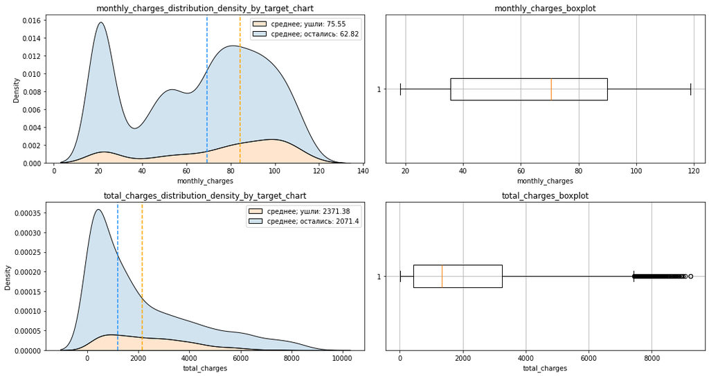

```python
dist_density_charts(df)
```

Что видим:

1. Есть выбросы в колонке 'total_charges', однако вряд ли можно считать их аномалиями: значения находятся в разумных пределах.
2. Распределение сумм месячных платежей бимодальное с двумя пиками в районе 20 и ±80. Наиболее вероятно, что это связано с особенностями тарифов и пакетами предоставляемых услуг, отсюда клиентов можно поделить на две условные группы: пользующихся базовыми тарифами и пакетами и пользующихся тарифами и пакетами "плюс".
3. В среднем чаще уходят клиенты, платящие по тарифам "плюс". Это плохой сигнал для бизнеса: ему действительно нужно работать над удержанием т.н. "китов".
4. По общим суммам платежей примерно та же картина: в среднем ушедшие платят ощутимо больше, чем оставшиеся.

Такая картина будет неполной, поэтому посмотрим на распределение клиентов по датам (месяцам) заключения контрактов, а также на диаграмму рассеяния с группировкой по таргету.

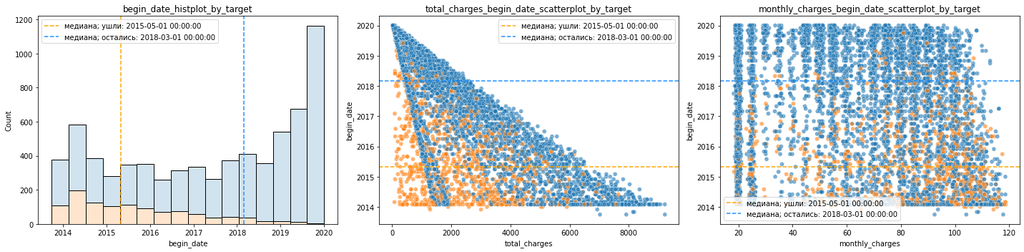

```python
date_charts(df)
```

Теперь начинает потихоньку вырисовываться портрет среднего "уходильщика":

1. В среднем договор расторгают наиболее давние клиенты.
2. По сумме платежей есть различия: обычно расторгающие договор клиенты являются давними и платят в общем небольшую (среднюю) сумму, однако их месячные платежи довольно высоки. Это говорит о том, что данные клиенты расторгли договор довольно быстро, хоть и заключили его довольно давно, поэтому как таковыми 'давними' они не являются. Исходя из этой находки, сформируем новый признак 'длительность', который покажет время пребывания клиента с компанией, и построим для него те же графики.

Итак, формируем длительность действия контракта. За точку отсчета возьмем крайнюю дату из столбца 'begin_date'. Рассчитаем длительность в днях. Но сначала на всякий случай проверим, как соотносятся крайние даты 'begin_date' и 'end_date'.

```python
print(pd.to_datetime(df.query('end_date != "no"')['end_date']).max())
print(df['begin_date'].max())
```

```
2020-01-01 00:00:00
2020-01-01 00:00:00
```

Крайняя дата в обоих случаях 2020-01-01, поэтому можно считать, что ошибок здесь нет и эта дата действительно является текущей датой (т.е. датой выгрузки данных из базы).

Формируем наш признак и проверяем:

```python
end_dates = pd.to_datetime(df['end_date'], errors='coerce').fillna('2020-01-01')
df['duration_days'] = (end_dates - df['begin_date']).dt.days.astype('int')

print(df['duration_days'].dtype)
print(df['duration_days'].head(10))
```

```
int64
0     245
1     245
2     122
3     396
4     122
5     245
6    2132
7    1887
8     184
9    1948
Name: duration_days, dtype: int64
```

Всё получилось, можно строить графики.

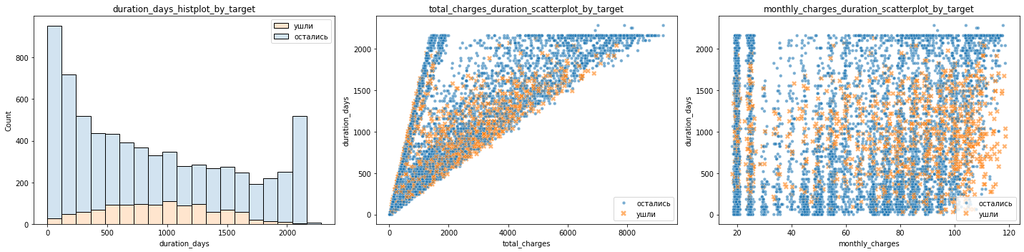

```python
duration_charts(df)
```

Теперь графики выглядят по-другому. Мы видим:

1. Уходят в основном клиенты со средней длительностью действия контракта. "Старожилы" и "новички", как правило, продолжают пользоваться услугами компании: среди наиболее долго взаимодействующих с компанией клиентов (порядка 2000 дней) практически нет тех, кто расторг договор, а среди новичков есть небольшой процент ушедших, которым, похоже, не подошли условия компании. Пик расторжения приходится на 1000 дней (примерно 2.73 года), и, похоже, это действительно как-то связано с изменением (или, наоборот, с отсутствием изменений) в перечне оказываемых услуг и тарифов или их цене. Уполномоченному отделу стоит обратить внимание на этот факт.
2. Ушедшие клиенты в среднем за весь срок действия договора платили плюс-минус среднюю цену (в районе 3000). Это соотносится с тем, что мы видели.
3. Ушедшие клиенты, как правило, платили довольно много помесячно, то есть скорее всего пользовались тарифами категории 'плюс'. Из этого вытекают два вывода:
   - Предварительно: причина расторжения договора, вероятно, заключается не в изменении цены, а в изменении качества и/или количества услуг самой компании или конкурентов;
   - Если причина кроется не в качестве или перечне предоставляемых услуг, то проблема стоит внимания аналитиков. В любом случае, на этот факт следует обратить внимание уполномоченному отделу.

С количественными признаками разобрались, теперь посмотрим на категориальные.

### Анализ категориальных признаков

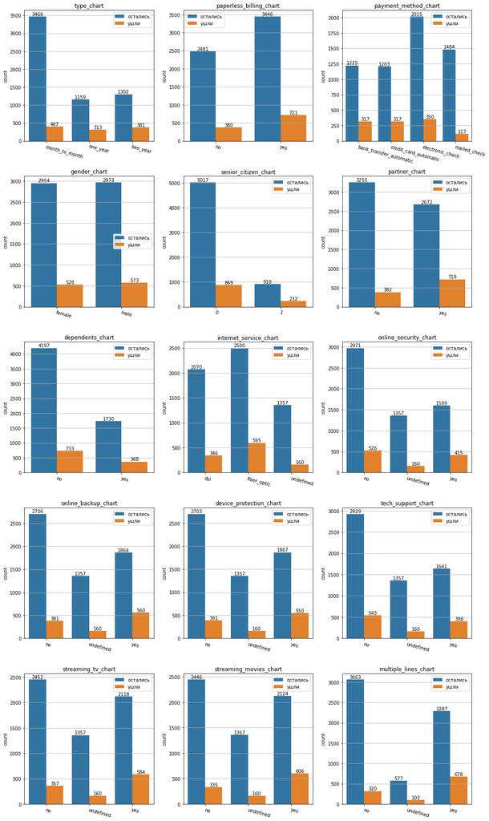

```python
bar_plotter(df)
```

По признакам:

1. тип оплаты - type:
   - Самый распространенный тип оплаты - помесячный.
   - В абсолютном выражении в разных категориях количество ушедших клиентов плюс-минус одинаковое. Здесь ничего особо интересного.
2. электронный расчетный лист - paperless_billing:
   - Самая многочисленная категория - безналичники.
   - ушедших в категории безналичников клиентов почти в 2 раза больше, однако скорее всего это связано с поправкой на количественное распределение клиентов по категориям.
3. тип платежа - payment_method:
   - Самая распространенная категория - электронный расчет.
   - В целом, количество ушедшхи клиентов по категориям в абсолютном выражении одинаковое, кроме категории 'mailed_check'. Количество ушедших клиентов этой категории сильно ниже как в абсолютном, так и в относительном выражении. Не особо понятно, с чем это может быть связано. Можно предположить, что признак связан с предыдущим, и пользователи, ведущие расчеты в бумагах более скрупулезно подходят к выбору провайдера, заключению и расторжению договоров по оказанию услуг. Эти пользователи также могут быть юридическими лицами, для которых расторжение подобного договора будет более болезненным, нежели для физ. лиц, хотя это не соотносится с признаком 'пол', где нет пропусков и категории юр. лица. Тем не менее, это всё только догадки.
4. пол клиента - gender:
   - Здесь клиенты распределены поровну, вряд ли этот признак несет в себе исчерпывающую информацию о таргете.
5. является ли клиент пенсионером:
   - Самая распространенная категория - "не пенсионер".
   - Здесь тоже что-то сложно сказать, относительные показатели ушедших/оставшихся внутри категорий сопоставимы (отношение оставшиеся / ушедшие = ~5.7 против ~3.95) с небольшим перекосом. Вероятно, молодым просто легче сменить провайдера и разобраться с бумажной волокитой.
6. информация о наличии супруга - partner:
   - Самая распространенная категория - "не в браке".
   - Вот здесь уже интересно. Похоже, люди, состоящие в браке, более склонны к смене провайдера, чем холостяки и холостячки. Предположу, что это связано с перечнем предоставляемых услуг: люди в браке (да ещё и, вероятно, с детьми) более склонны к подключению стриминга и ТВ, к приобретению антивируса и установке родительского контроля. Если же эти уходы пришлись преимущественно на тот период, когда компания таких услуг не предоставляла, это всё объясняет. Далее мы проверим эту гипотезу об услугах.
7. информация о детях - dependents:
   - Самая распространенная категория - бездетные.
   - Относительные выражения плюс-минус в норме, однако наблюдаемая картина несильно соотносится с распределением клиентов в предыдущем пункте. Может, дело не именно в стриминге и родительском контроле, а, например, в бэкап-облаке.
8. тип подключения - internet_service:
   - Самая распространенная категория - оптоволокно.
   - Относительное распределение клиентов тоже плюс-минус без аномалий.
9. блокировка опасных сайтов - online_security:
   - Самая распространенная категория - без блокировки опасных сайтов.
   - Тут тоже что-то сказать сложно, всё в норме.
10. облачное хранилище с резервными копиями - online_backup:
    - Самая распространенная категория - без облака.
    - Что интересно, в относительном выражении ушедших клиентов с подключенным бэкап-облаком больше, чем без него. Предположительно это может быть связано с качеством услуги или объемом предоставляемого хранилища: в общем, что-то клиентам здесь, вероятно, не нравится.
11. антивирус - device_protection:
    - Самая распространенная категория - без антивируса.
    - Здесь картина аналогичная предыдущему признаку.
12. выделенная линия тех. поддержки - tech_support:
    - Самая распространенная категория - без выделенной линии поддержки.
    - Здесь все более-менее выглядит безаномально.
13. стриминговое ТВ - streaming_tv:
    - Самая распространенная категория - без стримингового ТВ.
    - Тут тоже картина странноватая, ушедших клиентов с подключенной услугой в относительном выражении больше. Добавляем признак в копилку подозрительных к 'online_backup' и 'device_protection'. Может, пользователи недовольны качеством вещания или ассортиментом каналов.
14. каталог фильмов - streaming_movies:
    - Самая распространенная категория - без стриминг-кинотеатра.
    - Сюда применимо то же, что и к предыдущему признаку. Предположу, что пользователи могут быть недовольны ассортиментом фильмов или качеством стриминга.
15. телефонное подключение к нескольким линиям - multiple_lines:
    - Самая распространенная категория - без нескольких линий.
    - Опять то же, что и к предыдущим "подозрительным" признакам.

**Вывод:** Распределения клиентов относительно таргета по признакам, связанным с предоставляемыми компанией услугами, наталкивает на определенные мысли. Похоже, уходящие клиенты по какой-то причине недовольны услугами провайдера. Непонятно, связано это непосредственно с качеством услуг или с услугами, предлагаемыми конкурентами. Тема требует более детального разбирательства. Также количество и распределение клиентов по таргету в заполненных пропусках в тех же признаках остается неизменным. Скорее всего, противореча ранее обозначенному предположению, на уход пользователя не влияет наличие или отсутствие той или иной услуги, проблема кроется в самой услуге непосредственно.

Далее попытаемся проверить предположение о наличии / неналичии определенных услуг и связи с этим ухода пользователей.

|  | customer_id | begin_date | end_date | type | paperless_billing | payment_method | monthly_charges | total_charges | gender | senior_citizen | ... | internet_service | online_security | online_backup | device_protection | tech_support | streaming_tv | streaming_movies | multiple_lines | quit | duration_days |
| --- | --- | --- | --- | --- | --- | --- | --- | --- | --- | --- | --- | --- | --- | --- | --- | --- | --- | --- | --- | --- | --- |
| 625 | 0917-EZOLA | 2013-10-01 | no | two_year | yes | bank_transfer_automatic | 104.15 | 7915.40 | male | 1 | ... | fiber_optic | no | yes | yes | no | yes | yes | yes | 0 | 2283 |
| 2003 | 2889-FPWRM | 2013-10-01 | no | one_year | yes | bank_transfer_automatic | 117.80 | 9221.38 | male | 0 | ... | fiber_optic | yes | yes | yes | yes | yes | yes | yes | 0 | 2283 |
| 6055 | 8580-QVLOC | 2013-10-01 | no | two_year | no | credit_card_automatic | 92.45 | 7026.20 | female | 1 | ... | dsl | yes | yes | yes | yes | yes | yes | yes | 0 | 2283 |

3 rows × 22 columns

```
quit
0    0.829251
1    0.170749
Name: proportion, dtype: float64
quit
0    0.894529
1    0.105471
Name: proportion, dtype: float64
undef_mean_begin_date: 2017-04-10 08:36:03.527490560
def_mean_begin_date: 2017-07-05 20:20:43.506921472
```

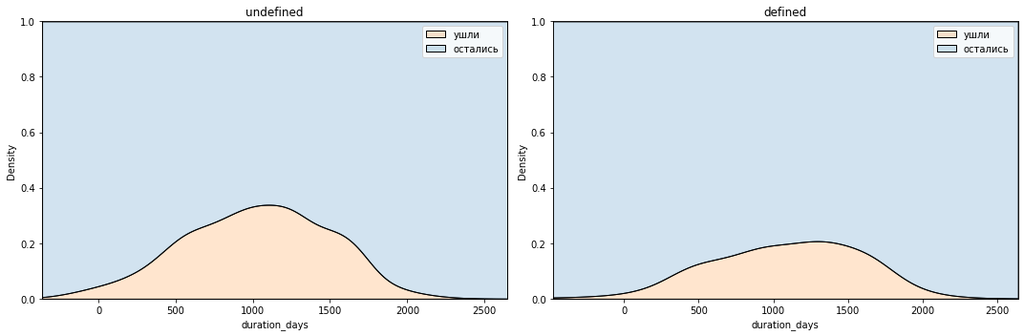

```python
facilities = ['internet_service',
              'online_security',
              'online_backup',
              'device_protection',
              'tech_support',
              'streaming_tv',
              'streaming_movies'
             ]
filtered_facilities_undef = df[~df[facilities].apply(lambda x: True if tuple(x.values) == tuple(['undefined' for i in  range(len(facilities))]) else False, axis=1)]
filtered_facilities_def = df[df[facilities].apply(lambda x: True if tuple(x.values) == tuple(['undefined' for i in  range(len(facilities))]) else False, axis=1)]

display(filtered_facilities_undef.query('begin_date == begin_date.min()'))

print(filtered_facilities_undef['quit'].value_counts(normalize=True))
print(filtered_facilities_def['quit'].value_counts(normalize=True))
print('undef_mean_begin_date: {}'.format(filtered_facilities_undef['begin_date'].mean()))
print('def_mean_begin_date: {}'.format(filtered_facilities_def['begin_date'].mean()))

fig, ax = plt.subplots(1, 2, figsize=(15, 5))

sns.kdeplot(data=filtered_facilities_undef, x='duration_days', hue='quit', ax=ax[0], multiple='fill', legend='full', alpha=0.2)
ax[0].set_title('undefined')
ax[0].legend(labels=['ушли', 'остались'])

sns.kdeplot(data=filtered_facilities_def, x='duration_days', hue='quit', ax=ax[1], multiple='fill', legend='full', alpha=0.2)
ax[1].set_title('defined')
ax[1].legend(labels=['ушли', 'остались'])

fig.tight_layout()
plt.show()
```

Похоже, доп. услуги были у провайдера с самого начала, и уход пользователей не зависит от того, что они появились только со временем. Проверим возможную корреляцию длительности и дат для пользователей, услуги для которых известны и для которых не известны, с распределением по таргету.

**Вывод:** видимая зависимость между известным и неизвестным типом услуг и длительностью, а также расторжением контракта безусловно есть, однако её природа остается тайной, покрытой мраком. Видна определенная историческая закономерность, возможно, в прошлом у компании происходило что-то такое, что побуждало клиентов чаще расторгать договор. Также неясно, неизвестные услуги являются проблемой выгрузки или самих данных непосредственно; данная проблема требует более детального изучения аналитиками компании. Тем не менее, даже с учетом недостатка информации, открытая закономерность должна положительно сказаться на моделировании и помочь предупреждать подобные тренды в будущем.

### Вывод по разделу

1. От компании уходят преимущественно те, кто платит по договору выше среднего в месяц. С этим действительно надо что-то делать.
2. Скорее всего отток клиентов связан непосредственно с услугами компании, однако неясно, это связан он с их качеством или условиями рынка. Требуется более масштабный и детальный анализ. Признаки с услугами, скорее всего, при моделировании будут учтены как определяющие.
3. Уходят преимущественно наиболее старые клиенты с ожидаемой средней длительностью действия контракта в ±1000 дней.
4. Прослеживается тренд оттока; учитывая пункт выше, он носит предположительно исторический характер, а также как-то связан с состоянием компании или исторической рыночной конъюнктурой.
5. Есть относительные различия в оттоке пользователей с установленными и неустановленными услугами. Неустановленные услуги (пропуски) могут представлять маску других услуг или уже имеющихся с разным распределением по категориям. В любом случае, имеющейся информации должно оказаться достаточно для моделирования, однако было бы неплохо в дальнейшем уточнить категории и/или избегать ошибок при выгрузке.

## шаг. Корреляционный анализ

Построим матрицу корреляции признаков для нашего датасета, но сначала для удобства реорганизуем его. Признаки с началом и окончанием даты удалим - первый неинформативен, а второй грозит утечкой данных.

```python
data = df[['customer_id',
           'total_charges',
           'monthly_charges',
           'duration_days',
           'type',
           'paperless_billing',
           'payment_method',
           'internet_service',
           'online_security',
           'online_backup',
           'device_protection',
           'tech_support',
           'streaming_tv',
           'streaming_movies',
           'multiple_lines',
           'gender',
           'senior_citizen',
           'partner',
           'dependents',
           'quit'
          ]]
```

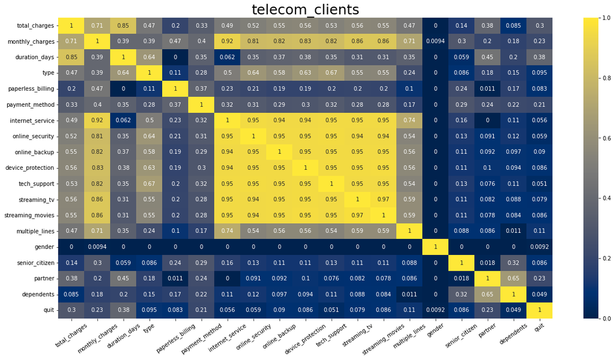

```python
fig, ax = plt.subplots(figsize=(20, 10))

sns.heatmap(data.drop('customer_id', axis=1).phik_matrix(interval_cols=['monthly_charges', 'total_charges', 'duration_days']),
            annot=True,
            cmap='cividis',
           ).tick_params('x',
                         labelrotation=35
                        )

ax.set_title('telecom_clients', fontsize=25)

plt.show()
```

Что видим, ключевые моменты:

1. Признак 'gender' вообще практически никак не коррелирует с другими признаками. Исключения составляют таргет и ежемесячная сумма платежей. Признак удалять не будем, так как он может оказаться полезным в качестве уточняющего.
2. Видим жёлтый "островок" или кластер предоставляемых услуг в центре графика. коэффициент линейной корреляции между собой они держат высокий (>0.9), однако их удаление под большим вопросом: все они по-разному коррелируют с таргетом, поэтому их совокупность и, вероятно, даже каждый из них в итоге может оказаться полезным. Линейные алгоритмы в такой ситуации использовать имеет мало смысла, поэтому стоит попробовать нелинейные, в особенности деревья решений и бустинги.
3. Все услуги крепко связаны с 'monthly_charges'. Это логично, ведь от набора услуг (пакета) зависит и месячная плата.
4. Единственный коэффициент корреляции >0.9 вне кластера - между признаками 'internet_service' и 'monthly_charges'. Та же история, скорее всего 'internet_service' будет уточняющим при моделировании.

Итак, анализ завершен, поэтому можно приступать к подготовке данных и обучению моделей.

## шаг. Подготовка данных

Поскольку мы будем использовать преимущественно древесные алгоритмы, а не линейные, кодировать категориальные признаки методом OHE нет смысла, поэтому применим OrdinalEncoder. Также, по идее, нет необходимости масштабировать количественные признаки (тем более что их всего три штуки), однако, пожалуй, на всякий случай попробуем несколько методов масштабирования в пайплайне при подборе гиперпараметров. Сэмплируем тренировочную выборку методом SMOTETomek: хоть мы и используем устойчивую к дисбалансу метрику ROC-AUC, наши данные не сказать что сильно разнообразны (у нас всего три количественных, т.е. диапазонально обширных признака), и такой метод сэмплирования должен помочь моделям научиться более легко распознавать и классифицировать пограничные объекты. Также перекодируем ранее заполненные пропуски так, чтобы при общей кодировке все они имели одинаковое значение (-1).

**Примеч.** категориальную колонку 'senior_citizen' для кодирования мы не указываем, так как она уже, по сути закодирована.

```python
data = data.mask(data == 'undefined')
X = data.drop(['customer_id', 'quit'], axis=1)
y = data['quit']

num_cols = ['total_charges', 'monthly_charges', 'duration_days']
cat_cols = X.drop(num_cols + ['senior_citizen'], axis=1).columns.to_list()

X_train, X_test, y_train, y_test = train_test_split(X, y, test_size=TEST_SIZE, random_state=RANDOM_STATE, stratify=y)

encoder = OrdinalEncoder(handle_unknown='use_encoded_value',
                         encoded_missing_value=-1,
                         unknown_value=np.nan
                        )

train_encoded = pd.DataFrame(encoder.fit_transform(X_train[cat_cols]),
                             columns=encoder.get_feature_names_out(), index=X_train.index
                            )
test_encoded = pd.DataFrame(encoder.transform(X_test[cat_cols]),
                            columns=encoder.get_feature_names_out(), index=X_test.index
                           )

X_train = pd.concat([X_train[num_cols], train_encoded], axis=1)
X_test = pd.concat([X_test[num_cols], test_encoded], axis=1)

sampler = SMOTETomek(random_state=RANDOM_STATE)
X_train_res, y_train_res = sampler.fit_resample(X_train, y_train)
```

Создаем объект ColumnTransformer для масштабирования количественных признаков при подборе параметров.

```python
dataprep = ColumnTransformer(

    [
        ('num', 'passthrough', num_cols)
    ],
    remainder='passthrough'
)
```

Создаем общую пайплайн-модель с учетом масштабирования.

```python
pipe_model = Pipeline(
    [
        ('prep', dataprep),
        ('model', DecisionTreeClassifier(random_state=RANDOM_STATE))
    ]
)
```

Подготовка завершена, можно приступать к обучению моделей.